# Habitat selection analyses

03 April, 2025

At this point I have (1) randomly sampled available habitat on a ratio of 6 available to 1 used points; and (2) matched up all of these points with environmental data - specifically, SST, bathymetry, SSH, and chlorophyll. Now it’s time to do some modelling.

To ensure appropriate model fit, I’ll be working on each species/colony separately. I can think about integrating them later, if the residual distributions etc are similar.

## Black-browed albatrosses

### Bird Island

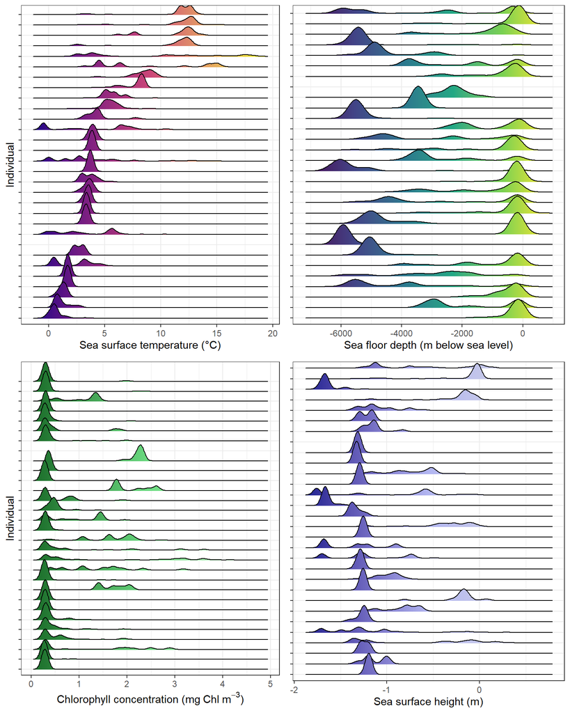

Next, let’s look at some covariates. We suspect that distance from the colony correlates with bathymetry, but let’s look at this for other variables too.

**Figure 2.** *Correlations between chosen environmental variables.*

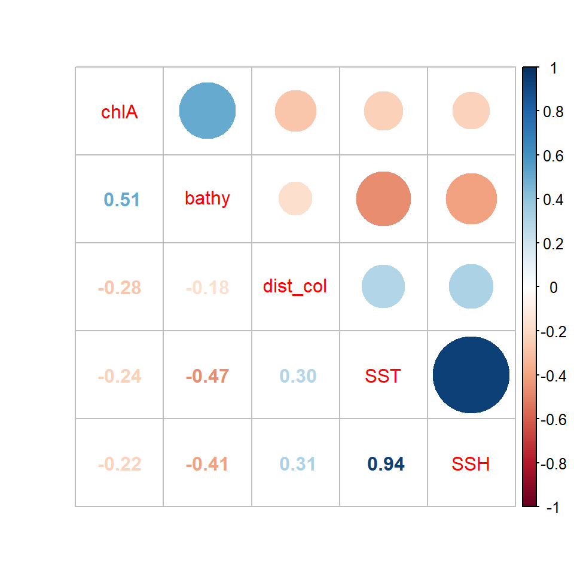

Surprisingly, SST and SSH are extremely well correlated - it turns out that they do indeed have a strong spatial correlation, particularly due to e.g. El Nino events, e.g. see:

Leuliette, E. W., & Wahr, J. M. (1999). Coupled pattern analysis of sea surface temperature and TOPEX/Poseidon sea surface height. *Journal of Physical Oceanography, 29*(4), 599–611. https://doi.org/10.1175/1520-0485(1999)029<0599:CPAOSS>2.0.CO;2

Apart from this, the correlations don’t seem very worrying. In response to these correlations, I’ll drop SSH because otherwise I fall folly to multiple testing.

#### Model structure

Finally, let’s build the model. After having issues fitting single environmental variables (specifically, the AUC was very low, suggesting poor predictive performance), I realised that a maximal model including all the predictors might be better. Indeed, I get better AUC and fit (see below).

The generalized linear mixed model (GLMM) used in this analysis is:

$$\text{logit}(\Pr(\text{used} = 1)) =
\beta_0 + \beta_1 \cdot \text{sst} + \beta_2 \cdot \text{sst}^2 +
\beta_3 \cdot \text{bathy} + \beta_4 \cdot \text{bathy}^2 + \beta_5
\cdot \text{chl} + \beta_6 \cdot \text{dist col} + \beta_7 \cdot
\text{phase} + U_{\text{ID}} + U_{\text{ID}}^{\text{sst}} \cdot
\text{sst} + U_{\text{ID}}^{\text{bathy}} \cdot \text{bathy} +
U_{\text{ID}}^{\text{chl}} \cdot \text{chl}$$

where:

- $\beta_0$ is the intercept,
- $\beta_1$–$\beta_{7}$ are the fixed effects of each environmental variable ($sst$, $bathy$, $chlA$), breeding phase ($phase$), and distance from the colony in km ($dist col$)
- $U_{\text{ID}}$ is the individual-level random intercept,
- $U_{\text{ID}}^{\text{sst}}$, $U_{\text{ID}}^{\text{bathy}}$, and
- $U_{\text{ID}}^{\text{chl}}$ are **individual-level random slopes** for **SST, bathymetry, and chlorophyll**, allowing individuals to have **different responses** to these variables.

Both SST and bathymetry were fitted with quadratic effects based on exploratory modelling. For SST, it looks like birds select medium-low temperatures; for bathymetry it looks like birds prefer shallow and deep areas (possibly confounded by colony distance, but we’ll get on to that). Models fitted with quadratic SST and bathymetry are a significiantly better fit based on AIC and an ANOVA comparison. The binned residual plot also looks considerably better, and the AUC improves (marginally, as it was reasonably good to begin with). Most importantly, I have no convergence issues with this model structure.

I have not included quadratic random slopes as this gets very complicated and I’m not sure I have the data to handle it. So for now, we are assuming that all birds have the same quadratic preference (same slope shape) but this can ‘shift’.

Now, I’ll fit the model and look at its diagnostics.

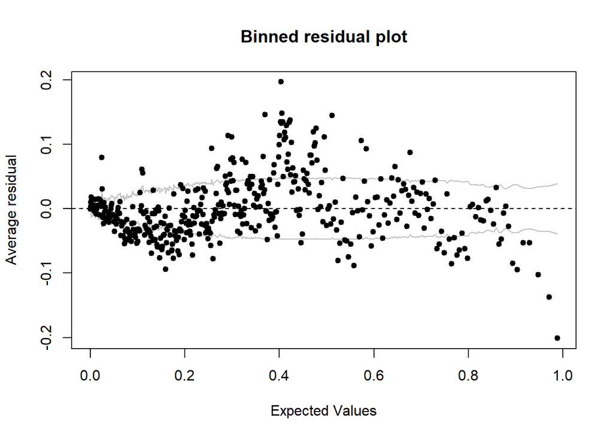

#### Model predictions

**Figure 3.** *Predicted probabilities of use for each fixed effect.*

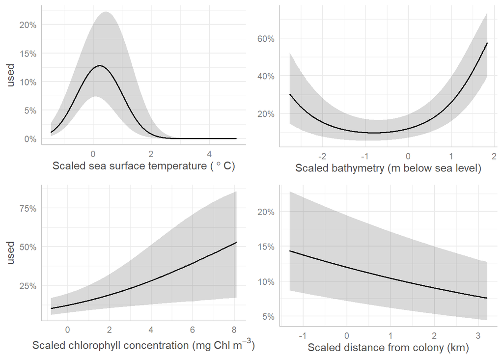

#### Individual effects

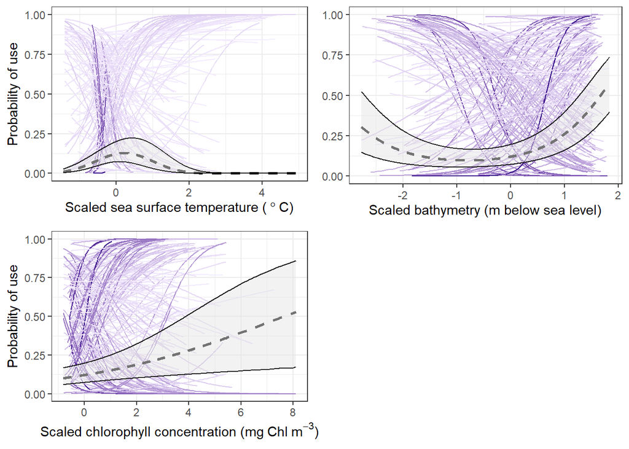